# My YouTube Viewing Habits: A Visual Data Story

## Which video types keep me most engaged?

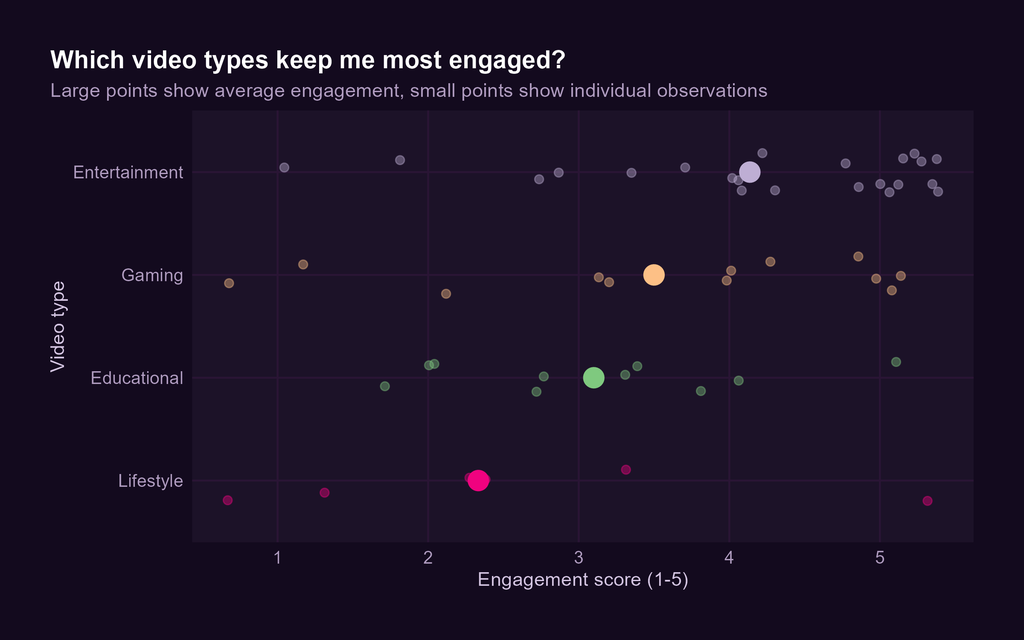

Dot plot showing average and individual engagement scores for four video types, with Entertainment scoring highest and Lifestyle lowest

Entertainment videos are clearly my favorite, they consistently score the highest engagement. Lifestyle videos on the other hand just don’t seem to hold my attention, scoring the lowest on average.

## Do I watch certain video types to completion?

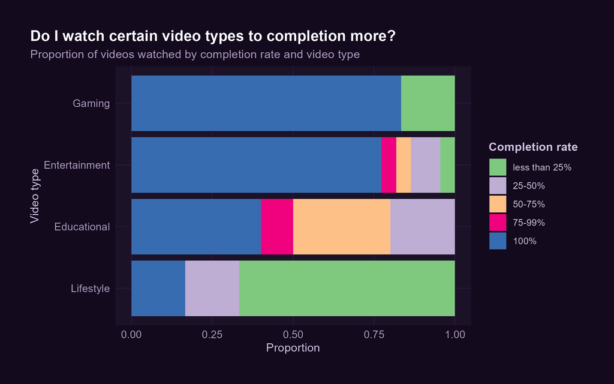

Stacked bar chart showing Gaming videos are most frequently watched to completion while Lifestyle videos are most frequently quit early

Gaming videos are most likely to be watched to completion, with the majority of them reaching 100%. In contrast, Lifestyle videos show the lowest completion rates, this lines up with lower engagement scores seen in the previous plot.

## Does the time I watch affect my engagement?

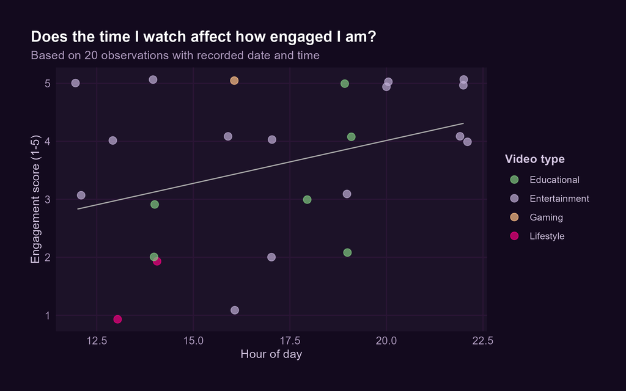

Scatter plot of hour of day versus engagement score with a positive linear trend line, coloured by video type

## What does this tell me?

Across the 50 observations, Entertainment and Gaming videos consistently showed higher engagement and completion rates, while Lifestyle videos were frequently abandoned early. Later viewing hours were also associated with slightly higher engagement, suggesting my attention and interest in content shifts throughout the day.